# R Notebook

### Completed by Connor Lenio. Email: cojamalo@gmail.com. Completion Date: May 11, 2017.

### Sources

This notebook includes information from the following webpages (Accessed 5/11/2017): * https://rdrr.io/cran/BAS/ * https://cran.r-project.org/web/packages/BAS/vignettes/BAS-vignette.html * https://www2.stat.duke.edu/courses/Spring17/sta521/knitr/Lec-14-BMA/bma.pdf

### Load Packages

```r
library(DAAG)
library(AICcmodavg)
library(BAS)
library(dplyr)
if(!exists("tree_lm", mode="function")) source("/Users/cojamalo/Documents/GitHub/Multiple-Linear-Reg-Tools/mult_regres.R")
```

### Source Data

```r
data(mtcars)
```

### Transform any variables if needed

`find_best_trans` finds best fits using prediction error as way to determine best fit (specifically, LOOCV)

```r
new_mtcars <- add_best_trans(find_best_trans(mpg,mtcars),mtcars)
```

```
[1] "Processing, please wait....."
```

```
essentially perfect fit: summary may be unreliableessentially perfect fit: summary may be unreliable
```

```r
glimpse(new_mtcars[,(ncol(mtcars)+1):ncol(new_mtcars)])
```

```
Observations: 32
Variables: 8
$ recip_disp <dbl> 0.006250000, 0.006250000, 0.009259259, 0.003875969, 0.002777778, 0.004444444, 0.002777778, 0.006816633, 0.007102273, 0.005966587, 0.005966587...
$ log_wt     <dbl> 0.9631743, 1.0560527, 0.8415672, 1.1678274, 1.2354715, 1.2412686, 1.2725656, 1.1600209, 1.1474025, 1.2354715, 1.2354715, 1.4036430, 1.3164082...
$ recip_hp   <dbl> 0.009090909, 0.009090909, 0.010752688, 0.009090909, 0.005714286, 0.009523810, 0.004081633, 0.016129032, 0.010526316, 0.008130081, 0.008130081...
$ log_cyl    <dbl> 1.791759, 1.791759, 1.386294, 1.791759, 2.079442, 1.791759, 2.079442, 1.386294, 1.386294, 1.791759, 1.791759, 2.079442, 2.079442, 2.079442, 2...
$ drat^2     <dbl> 15.2100, 15.2100, 14.8225, 9.4864, 9.9225, 7.6176, 10.3041, 13.6161, 15.3664, 15.3664, 15.3664, 9.4249, 9.4249, 9.4249, 8.5849, 9.0000, 10.43...
$ log_carb   <dbl> 1.3862944, 1.3862944, 0.0000000, 0.0000000, 0.6931472, 0.0000000, 1.3862944, 0.6931472, 0.6931472, 1.3862944, 1.3862944, 1.0986123, 1.0986123...
$ recip_gear <dbl> 0.2500000, 0.2500000, 0.2500000, 0.3333333, 0.3333333, 0.3333333, 0.3333333, 0.2500000, 0.2500000, 0.2500000, 0.2500000, 0.3333333, 0.3333333...
$ recip_qsec <dbl> 0.06075334, 0.05875441, 0.05373455, 0.05144033, 0.05875441, 0.04945598, 0.06313131, 0.05000000, 0.04366812, 0.05464481, 0.05291005, 0.0574712...
```

### Run the BAS linear regression - Creates the BMA

```r
cars.ZS =  bas.lm(mpg ~ .,
                   data=new_mtcars,
                  method = "deterministic",
                   prior="ZS-null",
                   modelprior=uniform())
```

#### Method

By default, BAS will try to enumerate all models, using the default method=“BAS”. An alternative to method=“BAS”:

- method=“deterministic” - like BAS but possibly faster?
- method=“BAS” uses Bayesian Adaptive Sampling (without replacement) using the sampling probabilities given in initprobs;
- method=“MCMC” samples with replacement via a MCMC algorithm that combines the birth/death random walk in Hoeting et al (1997) of MC3 with a random swap move to interchange a variable in the model with one currently excluded as described in Clyde, Ghosh and Littman (2010);
- method=“MCMC+BAS” runs an initial MCMC to calculate marginal inclusion probabilities and then samples without replacement as in BAS. For BAS, the sampling probabilities can be updated as more models are sampled.

We recommend “MCMC+BAS” or “MCMC” for high dimensional problems where enumeration is not feasible. MCMC example

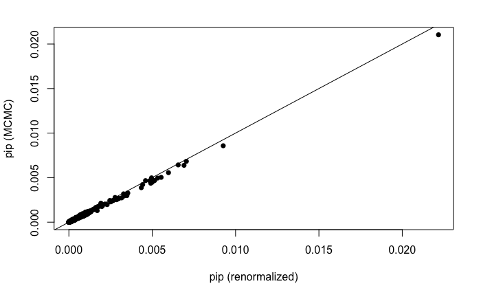

```r
cars.MCMC =  bas.lm(mpg ~ .,
                   data=new_mtcars,
                   prior="ZS-null",
                   modelprior=uniform(),
                   method = "MCMC", MCMC.iterations = 10^6)
diagnostics(cars.MCMC, type="model", pch=16)
```

#### Prior

By default, BAS will use the prior=“ZS-null” or the Zellner-Siow Cauchy prior. Alternatives in order of sophistircation:

- g-prior - needs g, a scalar used in the covariance of Zellner’s g-prior, Cov(beta) = sigma^2 g (X’X)^-1
- ZS-null - special case of hyper-g? where alpha = n (sample size) - Use this typically
- hyper-g - needs “alpha”, a scalar > 0. The hyper.g(alpha) is equivalent to CCH(alpha -2, 2, 0). Liang et al recommended values in the range 2 < alpha_h <= 3
- hyper-g/n - needs “alpha”, a scalar > 0, recommended 2 < alpha <= 3

Other prior distributions on the regression coefficients may be specified using the prior argument, and include:

“BIC” “AIC “hyper-g-laplace” “ZS-null” “EB-local” “EB-global”

#### Modelprior

The prior distribution over the models is a uniform() distribution which assigns equal probabilities to all models. As far as I can understand, this is the prior over the size of the model (# of variables). Other modelpriors: * modelprior=uniform() The Uniform prior distribution is a commonly used prior in BMA, and is a special case of the indpendent Bernoulli prior with probs=.5. The implied prior distribution on model size is binomial(p, .5).

- modelprior=beta.binomial(1,1) The beta-binomial distribution on model size is obtained by assigning each variable inclusion indicator independent Bernoulli distributions with probability w, and then giving w a beta(alpha,beta) distribution. Marginalizing over w leads to the distribution on model size having the beta-binomial distribution. The default hyperparaeters lead to a uniform distribution over model size.
- modelprior=Bernoulli(probs=.5) The independent Bernoulli prior distribution is a commonly used prior in BMA, with the Uniform distribution a special case with probs=.5. If all indicator variables have a independent Bernoulli distributions with common probability probs, the distribution on model size binomial(p, probs) distribution.
- modelprior=tr.poisson(4,10) - truncated poisson - all models over size 10 are given probability zero - also tr.beta.binomial and tr.power.prior In this case the distribution of the number of variables to be included has a Poisson distribution, with mean 4 (under no truncation), and the truncation point is at 10, so that all models with more than 10 (one half of cases rounded down) will have probability zero.

#### Initprobs

The last optional argument initprobs = eplogp provides a way to initialize the sampling algorithm and order the variables in the tree structure that represents the model space in BAS. The eplogp option uses the Bayes factor calibration of p-values −eplog(p)−eploga(p) to provide an approximation to the marginal inclusion probability that the coefficient of each predictor is zero, using the p-values from the full model. Other options for initprobs include:

- “uniform” - the default, gives equal weight to all possible models
- eplogp - The eplogp option uses the Bayes factor calibration of p-values −eplog(p)−eploga(p) to provide an approximation to the marginal inclusion probability that the coefficient of each predictor is zero, using the p-values from the full model
- “marg-eplogp”“- The option “marg-eplogp” uses p-values from the p simple linear regressions (useful for large p or highly correlated variables).
- numeric vector of length p - can force inclusion of some variables - 1 for forced inclusion, 0.5 for uniform? example: initprobs=c(rep(0.5, times = 8), 1, rep(0.5, times = 10)), this means force the 9th variable to be included in final model and give uniform to rest

### Visualize Bayesian Model Diagnostics

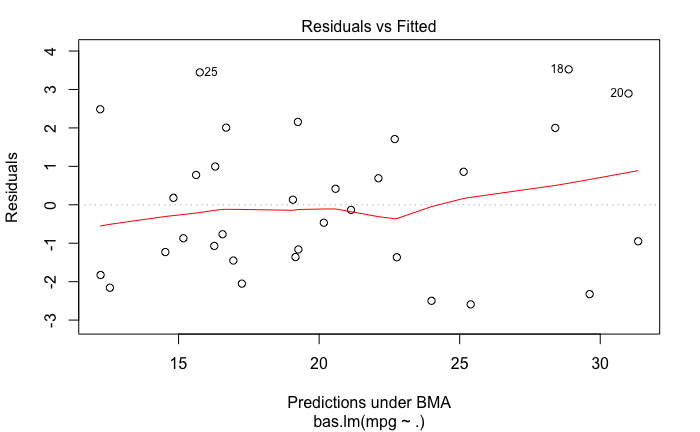

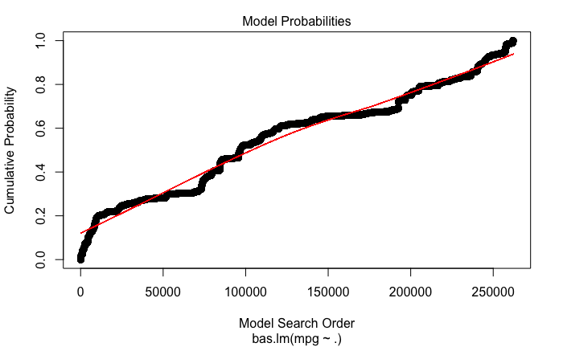

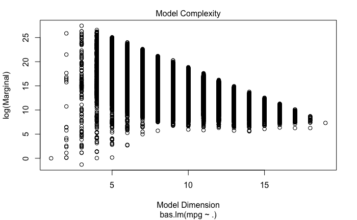

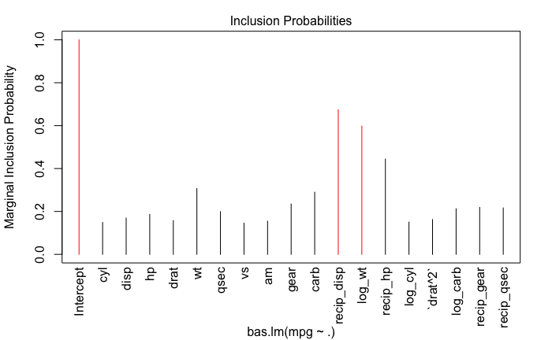

```r
plot(cars.ZS, ask=F)
```

### View the model features

#### Includes Marginal Posterior Inclusion Probabilities

```r
print(cars.ZS)
```

```
Call:
bas.lm(formula = mpg ~ ., data = new_mtcars, prior = "ZS-null",     modelprior = uniform(), method = "deterministic")


 Marginal Posterior Inclusion Probabilities:
 Intercept         cyl        disp          hp        drat          wt        qsec          vs          am        gear        carb  recip_disp      log_wt
    1.0000      0.1489      0.1693      0.1858      0.1572      0.3068      0.1988      0.1454      0.1550      0.2345      0.2897      0.6744      0.5979
  recip_hp     log_cyl    `drat^2`    log_carb  recip_gear  recip_qsec
    0.4441      0.1504      0.1624      0.2125      0.2189      0.2165
```

#### Includes top five models

```r
summary(cars.ZS)
```

```
           P(B != 0 | Y)  model 1    model 2    model 3   model 4    model 5
Intercept      1.0000000  1.00000  1.0000000  1.0000000  1.000000  1.0000000
cyl            0.1488508  0.00000  0.0000000  0.0000000  0.000000  0.0000000
disp           0.1692940  0.00000  0.0000000  0.0000000  0.000000  0.0000000
hp             0.1858386  0.00000  0.0000000  0.0000000  0.000000  0.0000000
drat           0.1572059  0.00000  0.0000000  0.0000000  0.000000  0.0000000
wt             0.3068115  0.00000  0.0000000  0.0000000  1.000000  0.0000000
qsec           0.1988135  0.00000  0.0000000  0.0000000  0.000000  0.0000000
vs             0.1453633  0.00000  0.0000000  0.0000000  0.000000  0.0000000
am             0.1550252  0.00000  0.0000000  0.0000000  0.000000  0.0000000
gear           0.2345458  0.00000  0.0000000  0.0000000  0.000000  1.0000000
carb           0.2896775  0.00000  0.0000000  0.0000000  0.000000  1.0000000
recip_disp     0.6744044  0.00000  1.0000000  1.0000000  1.000000  1.0000000
log_wt         0.5978581  1.00000  1.0000000  1.0000000  0.000000  0.0000000
recip_hp       0.4441430  1.00000  1.0000000  0.0000000  0.000000  0.0000000
log_cyl        0.1504319  0.00000  0.0000000  0.0000000  0.000000  0.0000000
`drat^2`       0.1624000  0.00000  0.0000000  0.0000000  0.000000  0.0000000
log_carb       0.2125121  0.00000  0.0000000  0.0000000  0.000000  0.0000000
recip_gear     0.2189260  0.00000  0.0000000  0.0000000  0.000000  0.0000000
recip_qsec     0.2164918  0.00000  0.0000000  0.0000000  0.000000  0.0000000
BF                    NA  1.00000  0.4175909  0.3178281  0.311503  0.2957805
PostProbs             NA  0.02140  0.0089000  0.0068000  0.006700  0.0063000
R2                    NA  0.89310  0.9030000  0.8840000  0.883800  0.9005000
dim                   NA  3.00000  4.0000000  3.0000000  3.000000  4.0000000
logmarg               NA 27.44214 26.5688825 26.2958910 26.275789 26.2239978
```

### Visualize variable selection

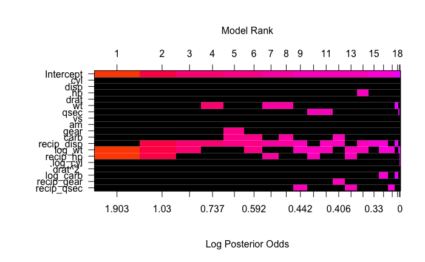

```r
image(cars.ZS, rotate=F)
```

### Visualize probability curves for coefficients of each variable

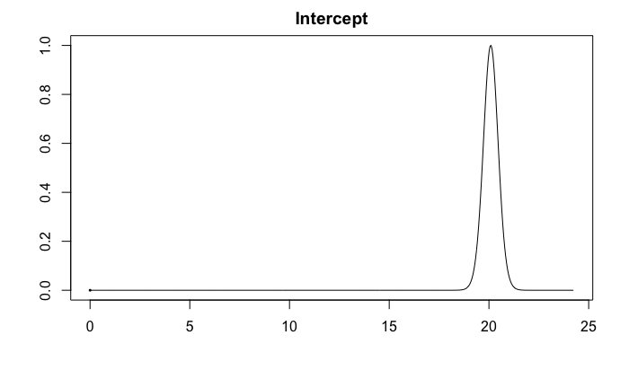

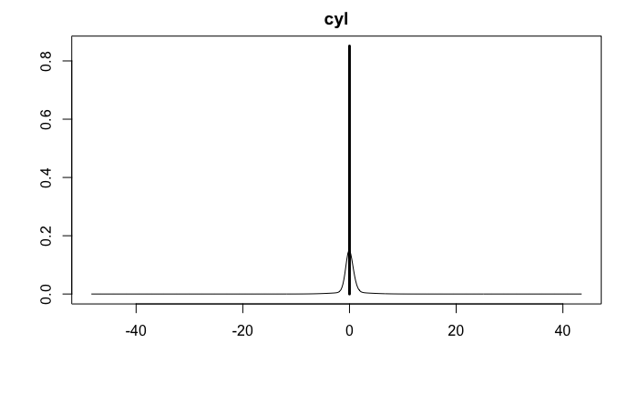

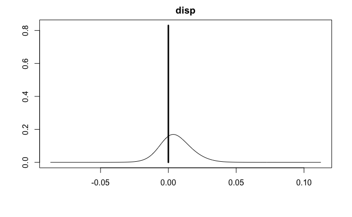

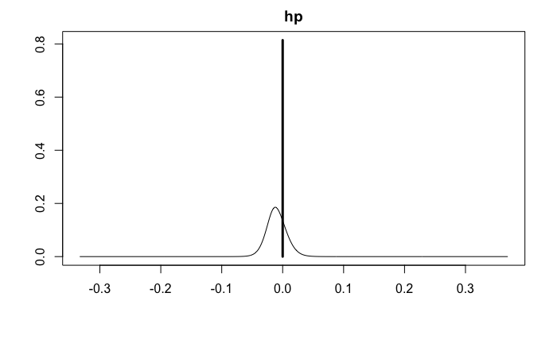

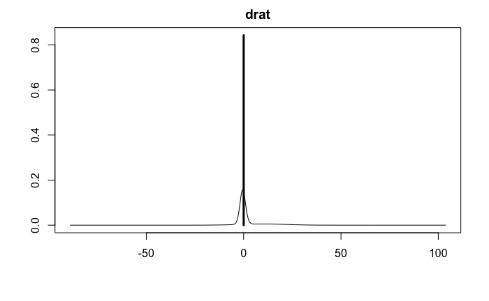

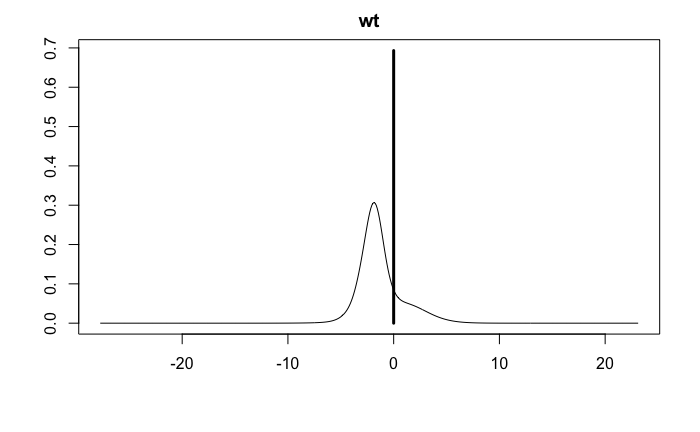

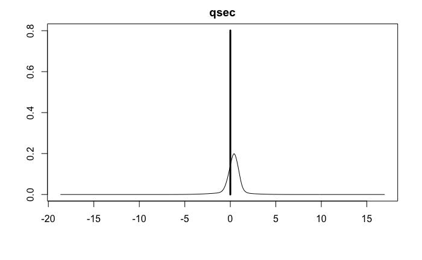

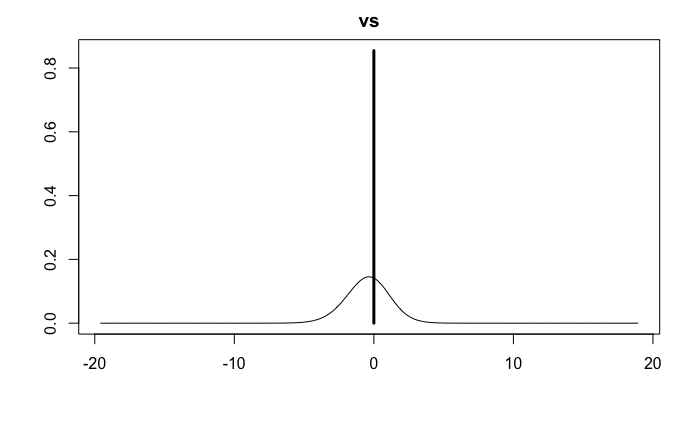

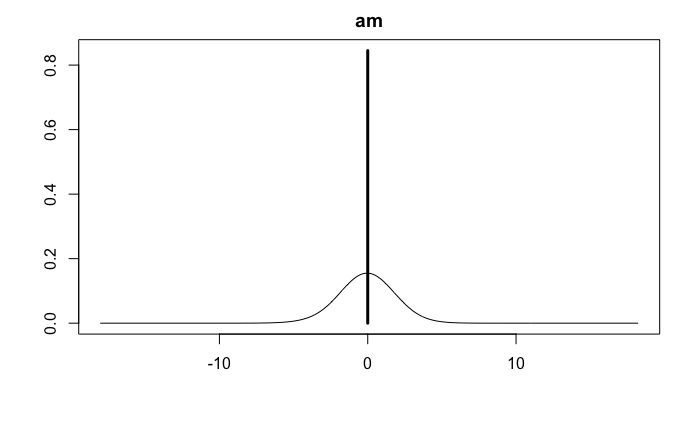

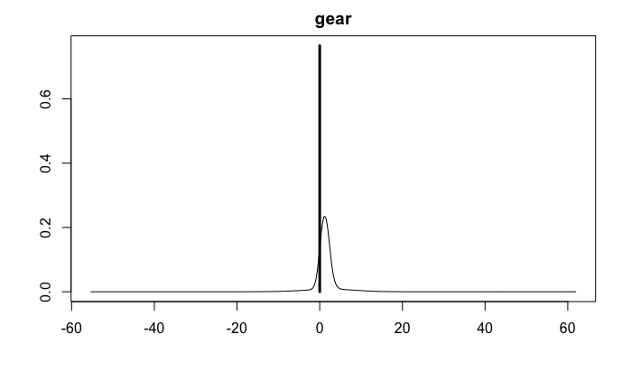

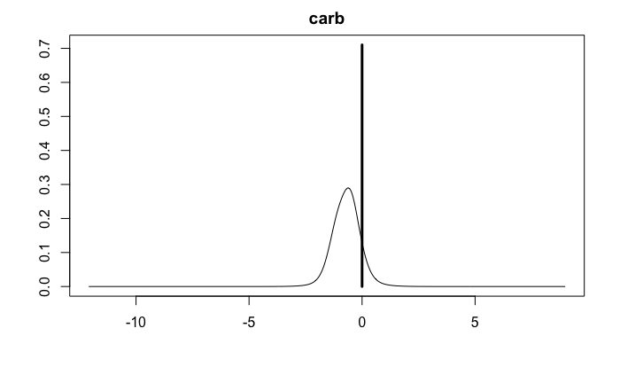

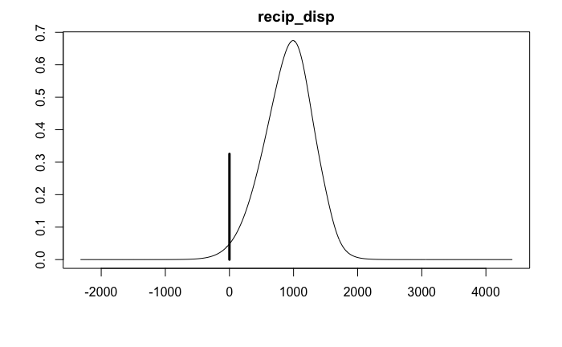

[7 more figures not shown]

```r
plot(coef(cars.ZS), ask=FALSE)
```

### View the variable coefficents with 95% credible intervales for each variable in the BMA

#### As a table

```r
confint(coef(cars.ZS))
```

```
                  2.5  %      97.5  %          beta
Intercept   1.930187e+01 2.081512e+01  2.009063e+01
cyl        -7.934882e-01 8.821663e-01  9.854417e-03
disp       -7.104089e-03 1.677748e-02  9.470535e-04
hp         -2.964148e-02 5.053324e-03 -1.849578e-03
drat       -2.721404e+00 1.534105e+00  2.866215e-01
wt         -4.119317e+00 1.251171e+00 -3.934786e-01
qsec       -3.049833e-01 1.038536e+00  6.462678e-02
vs         -1.803713e+00 1.105127e+00 -6.628114e-02
am         -1.644619e+00 1.927101e+00 -1.086100e-02
gear       -3.744749e-01 3.118411e+00  3.391926e-01
carb       -1.483762e+00 4.561183e-02 -2.006841e-01
recip_disp  0.000000e+00 1.480129e+03  6.198919e+02
log_wt     -1.729031e+01 6.815412e-03 -5.888464e+00
recip_hp    0.000000e+00 7.972014e+02  2.003870e+02
log_cyl    -4.395329e+00 4.678679e+00 -1.661106e-02
`drat^2`   -3.745222e-01 1.950470e-01 -5.915493e-02
log_carb   -3.013901e+00 5.733582e-01 -2.593064e-01
recip_gear -4.311075e+01 6.196973e+00 -2.603024e+00
recip_qsec -4.411955e+02 1.066698e+02 -3.035939e+01
attr(,"Probability")
[1] 0.95
attr(,"class")
[1] "confint.bas"
```

#### Visualize the previous table

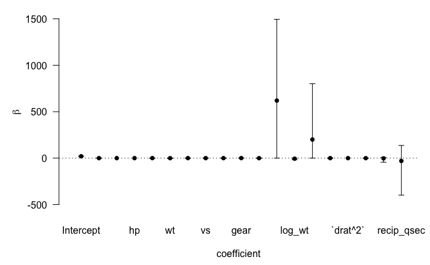

```r
plot(confint(coef(cars.ZS)))
```

#### Can also find confidence intervals for Highest probability model (HPM), MPM, BPM, etc

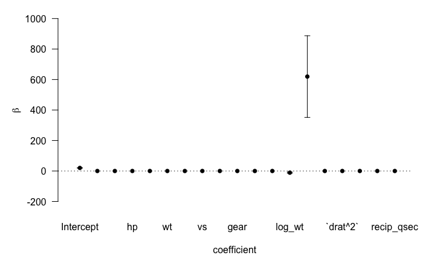

```r
plot(confint(coef(cars.ZS, estimator = "HPM")))
```

### Predictions and Model Summaries

Construct the “fitted” vectors to compare predictions to fitted values

```r
muhat.BMA = fitted(cars.ZS, estimator="BMA")
BMA  = predict(cars.ZS, estimator="BMA")
summary(BMA)
```

```
            Length  Class  Mode
fit              32 -none- numeric
Ybma             32 -none- numeric
Ypred       8388608 -none- numeric
postprobs    262144 -none- numeric
se.fit            0 -none- NULL
se.pred           0 -none- NULL
se.bma.fit        0 -none- NULL
se.bma.pred       0 -none- NULL
df           262144 -none- numeric
best         262144 -none- numeric
bestmodel    262144 -none- list
prediction        1 -none- logical
estimator         1 -none- character
```

#### Visualize the fitted versus predicted

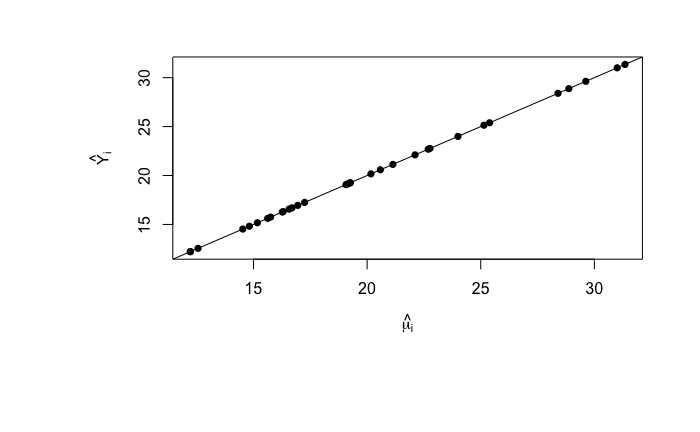

```r
par(mar=c(9, 9, 3, 3))
plot(muhat.BMA, BMA$fit,
     pch=16,
     xlab=expression(hat(mu[i])), ylab=expression(hat(Y[i])))
abline(0,1)
```

### Find the included variables for different model types

#### Highest probability model

```r
HPM = predict(cars.ZS, estimator="HPM")
(cars.ZS$namesx[HPM$bestmodel +1])[-1]
```

```
[1] "log_wt"   "recip_hp"
```

#### Median probability model

```r
MPM = predict(cars.ZS, estimator="MPM")
(cars.ZS$namesx[attr(MPM$fit, 'model') +1])[-1]
```

```
[1] "recip_disp" "log_wt"
```

#### Best predictive model

```r
BPM = predict(cars.ZS, estimator="BPM")
(cars.ZS$namesx[attr(BPM$fit, 'model') +1])[-1]
```

```
[1] "hp"         "qsec"       "am"         "recip_disp" "log_wt"     "recip_hp"   "log_carb"   "recip_qsec"
```

### Plot the fits for all major models - Shows agreement between models, easy to see similar models

[output not shown]

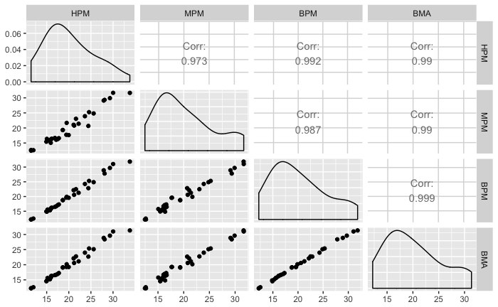

```r
library(GGally)
ggpairs(data.frame(HPM = as.vector(HPM$fit),  #this used predict so we need to extract fitted values
                   MPM = as.vector(MPM$fit),  # this used fitted
                   BPM = as.vector(BPM$fit),  # this used fitted
                   BMA = as.vector(BMA$fit))) # this used predict
```

#### Plot the fitted value errors - shows for ehich values in data model has greater uncertainty or not

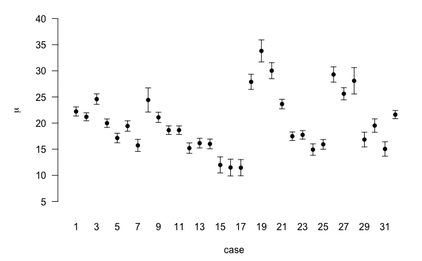

```r
errors = predict(cars.ZS, estimator="HPM", se.fit=TRUE)
cars.conf.fit = confint(errors, parm="mean")
cars.conf.pred = confint(errors, parm="pred")
plot(cars.conf.fit)
```

```r
RMSE_data <- cbind(cars.conf.pred, response = new_mtcars$mpg) %>% tbl_df %>% mutate(error = pred - response, SE = error^2)
summarize(RMSE_data, MSE = mean(SE), RMSE = sqrt(MSE))
```

| MSE | RMSE |
| --- | --- |
| 3.766918 | 1.940855 |

```r
errors = predict(cars.ZS, estimator="BPM", se.fit=TRUE)
cars.conf.fit = confint(errors, parm="mean")
cars.conf.pred = confint(errors, parm="pred")
plot(cars.conf.fit)
RMSE_data <- cbind(cars.conf.pred, response = new_mtcars$mpg) %>% tbl_df %>% mutate(error = pred - response, SE = error^2)
summarize(RMSE_data, MSE = mean(SE), RMSE = sqrt(MSE))
```

[output not shown]

```r
errors = predict(cars.ZS, estimator="BMA", se.fit=TRUE)
cars.conf.fit = confint(errors, parm="mean")
cars.conf.pred = confint(errors, parm="pred")
plot(cars.conf.fit)
RMSE_data <- cbind(cars.conf.pred, response = new_mtcars$mpg) %>% tbl_df %>% mutate(error = pred - response, SE = error^2)
summarize(RMSE_data, MSE = mean(SE), RMSE = sqrt(MSE))
```

[output not shown]

```r
errors = predict(cars.ZS, estimator="MPM", se.fit=TRUE)
cars.conf.fit = confint(errors, parm="mean")
cars.conf.pred = confint(errors, parm="pred")
plot(cars.conf.fit)
RMSE_data <- cbind(cars.conf.pred, response = new_mtcars$mpg) %>% tbl_df %>% mutate(error = pred - response, SE = error^2)
summarize(RMSE_data, MSE = mean(SE), RMSE = sqrt(MSE))
```

[output not shown]